# Reproducible Research: Peer Assessment 1

The assignment is to write a report that answers the questions detailed below. Ultimately, the entire assignment needs to be completed in a **single R markdown** document that can be processed by **knitr** and transformed into an *HTML* file. Further details on the assignment and on data used in this report can be found in *ReadMe* file.

### Loading and preprocessing the data

The data for this assignment is downloaded from a repository on GitHub. The dataset is stored in a comma-separated-value (CSV) file and there are a total of 17,568 observations in 3 columns.

```r
url <- "https://github.com/ipocepan/RepData_PeerAssessment1/blob/master/activity.zip"
if(!file.exists("activity.csv")) {
        download.file(url, destfile = "activity.zip", method = "curl")
        unzip("activity.zip")
}
activity_data <- read.csv("activity.csv", sep = ",", header = T, colClasses = c("numeric", "Date", "numeric"))
head(activity_data, 3)
```

```
##   steps       date interval
## 1    NA 2012-10-01        0
## 2    NA 2012-10-01        5
## 3    NA 2012-10-01       10
```

```r
str(activity_data)
```

```
## 'data.frame':    17568 obs. of  3 variables:
##  $ steps   : num  NA NA NA NA NA NA NA NA NA NA ...
##  $ date    : Date, format: "2012-10-01" "2012-10-01" ...
##  $ interval: num  0 5 10 15 20 25 30 35 40 45 ...
```

### What is mean total number of steps taken per day?

For this part of the assignment, the missing values in the data set will be excluded from calculations.

**1. Calculate the total number of steps taken per day**

The number of steps was aggregated per date, all the missing values were ignored.

```r
total_steps <- aggregate(steps ~ date, data = activity_data, FUN = sum, na.rm = T)
head(total_steps, 3)
```

```
##         date steps
## 1 2012-10-02   126
## 2 2012-10-03 11352
## 3 2012-10-04 12116
```

```r
dim(total_steps)
```

```
## [1] 53  2
```

**2. Make a histogram of the total number of steps taken each day**

The following image depicts distribution of the total number of steps taken each day. There are 22 bins with binwidth equal to 1000. The blue dashed line marks the average number of steps taken per day during this experiment.

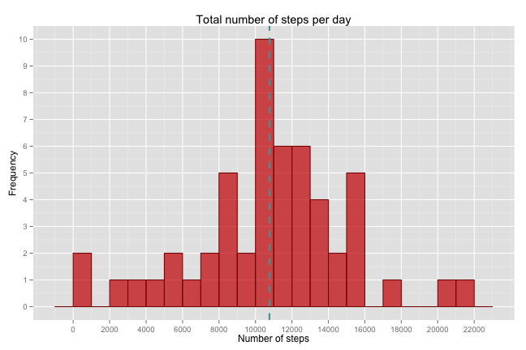

```r
library(ggplot2)
ggplot(data = total_steps, aes(steps)) +
        geom_histogram(binwidth = 1000, fill = "red3", col = "darkred", alpha = 0.7) +
        geom_vline(aes(xintercept = mean(steps)), color = "cadetblue", linetype = "dashed", size = 1) +
        labs(title = "Total number of steps per day", x = "Number of steps", y = "Frequency") +
        scale_y_continuous(breaks = seq(0, 10, by = 1)) +
        scale_x_continuous(breaks = seq(0, 22000, by = 2000))
```

**3. Calculate and report the mean and median of the total number of steps taken per day**

```r
mean(total_steps$steps)
```

```
## [1] 10766.19
```

```r
median(total_steps$steps)
```

```
## [1] 10765
```

### What is the average daily activity pattern?

**1. Make a time series plot of the 5-minute interval (x-axis) and the average number of steps taken, averaged across all days (y-axis)**

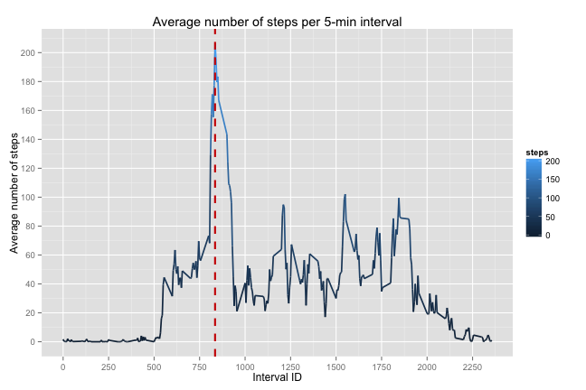

```r
mean_steps_data <- aggregate(steps ~ interval, data = activity_data, FUN = mean, na.rm = T)
max_int <- mean_steps_data[which.max(mean_steps_data$steps),]$interval

ggplot(data = mean_steps_data, aes(x = interval, y = steps)) +
        geom_line(aes(group = 1, col = steps), size = 0.8) +
        geom_vline(aes(xintercept = max_int), color = "red3", linetype = "dashed", size = 1) +
        labs(title = "Average number of steps per 5-min interval", x = "Interval ID", y = "Average number of steps") +
        scale_x_continuous(breaks = seq(0, 2355, by = 250)) +
        scale_y_continuous(breaks = seq(0, 210, by = 20))
```

**2. Which 5-minute interval, on average across all the days in the dataset, contains the maximum number of steps?**

```r
max_int
```

```
## [1] 835
```

On average across all the days, the maximum number of steps (206) is made during the 835 interval, which probably corresponds to *8:35 AM*. This interval is marked on the previous time series plot with red dashed line.

### Imputing missing values

Note that there are a number of days/intervals where there are missing values (coded as NA). The presence of missing days may introduce bias into some calculations or summaries of the data.

**1. Calculate and report the total number of missing values in the dataset**

```r
dim(activity_data[!complete.cases(activity_data),])
```

```
## [1] 2304    3
```

There are 2304 missing values in the dataset, which means that approximately 13% of the observations is incomplete.

**2. Devise a strategy for filling in all of the missing values in the dataset. Create a new dataset that is equal to the original dataset but with the missing data filled in.**

The missing values were imputed using the median value for each of the 5-minute intervals. For instance, if the median for the 215 interval was 0, all the NA’s for that interval were replaced by 0.

```r
library(plyr)
imputed_data <- ddply(activity_data, .(interval), mutate, int_median = median(steps, na.rm = T))
imputed_data$steps <- ifelse(is.na(imputed_data$steps), imputed_data$int_median, imputed_data$steps)
imputed_data$int_median <- NULL
```

**3. Make a histogram of the total number of steps taken each day.** Calculate and report the mean and median total number of steps taken per day. Do these values differ from the estimates from the first part of the assignment? What is the impact of imputing missing data on the estimates of the total daily number of steps?

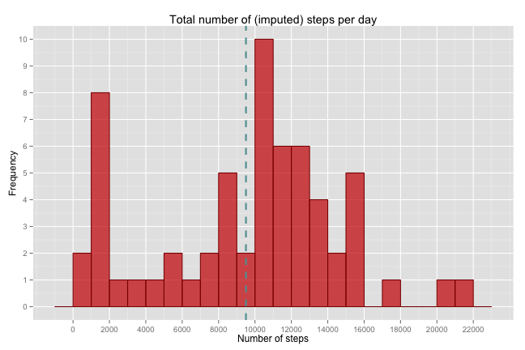

```r
steps_data <- aggregate(steps ~ date, data = imputed_data, FUN = sum)

ggplot(data = steps_data, aes(steps_data$steps)) +
        geom_histogram(binwidth = 1000, fill = "red3", col = "darkred", alpha = 0.7) +
        geom_vline(aes(xintercept = mean(steps_data$steps)), color = "cadetblue", linetype = "dashed", size = 1) +
        labs(title = "Total number of (imputed) steps per day", x = "Number of steps", y = "Frequency") +
        scale_y_continuous(breaks = seq(0, 10, by = 1)) +
        scale_x_continuous(breaks = seq(0, 22000, by = 2000))
```

```r
mean(steps_data$steps)
```

```
## [1] 9503.869
```

```r
median(steps_data$steps)
```

```
## [1] 10395
```

The average total number of steps per day for imputed data is 9503, which is significantly different from the average value of the original data. The median number of steps per day for imputed data is 10395, which is slightly different but still near the median value of the original data. Compared to the histogram of the original data, the histogram of the imputed data had a spike in the interval between 1000 and 2000 steps. If we compare the boxplots of the total daily number of steps for the original and the imputed data, we can see that the distribution has “shifted” to the left (towards the lower values) when the imputed values were introduced.

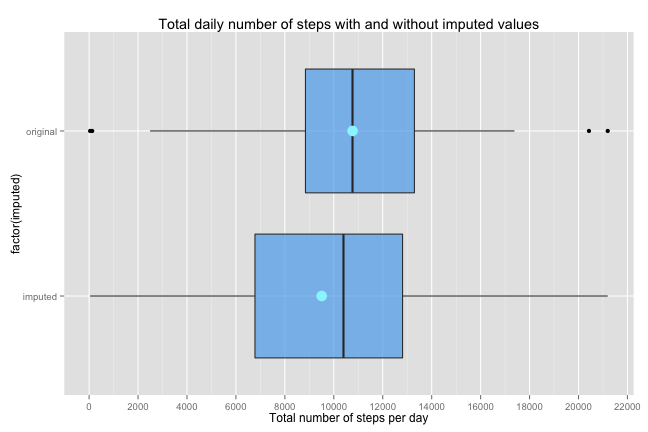

```r
total_steps$imputed <- "original"
steps_data$imputed <- "imputed"
boxplot_data <- rbind(total_steps, steps_data)

ggplot(boxplot_data, aes(factor(imputed), steps)) +
        geom_boxplot(fill = "steelblue2", alpha = 0.7) +
        labs(title = "Total daily number of steps with and without imputed values", y = "Total number of steps per day") +
        stat_summary(fun.y = mean, geom = "point", size = 5, col = "cadetblue1") +
        scale_y_continuous(breaks = seq(0, 22000, by = 2000)) +
        coord_flip()
```

### Are there differences in activity patterns between weekdays and weekends?

For this part the *weekdays()* function may be of some help here. Use the dataset with the filled-in missing values for this part.

**1. Create a new factor variable in the dataset with levels “weekday” and “weekend” indicating whether a given date is a weekday or weekend day.**

To determine whether a date is a weekday or not, we used format() funtion with the “%u” argument. Each date was assigned a value 1-7, i.e. Monday - 1, Sunday - 7.

```r
imputed_data$wdayID <- format(imputed_data$date, "%u")
imputed_data$wday[imputed_data$wdayID %in% c("6","7")] <- "weekend"
imputed_data$wday[imputed_data$wdayID %in% c("1","2","3","4","5")] <- "weekday"
imputed_data$wday <- as.factor(imputed_data$wday)
imputed_data$wdayID <- NULL
str(imputed_data)
```

```
## 'data.frame':    17568 obs. of  4 variables:
##  $ steps   : num  0 0 0 47 0 0 0 0 0 34 ...
##  $ date    : Date, format: "2012-10-01" "2012-10-02" ...
##  $ interval: num  0 0 0 0 0 0 0 0 0 0 ...
##  $ wday    : Factor w/ 2 levels "weekday","weekend": 1 1 1 1 1 2 2 1 1 1 ...
```

**2. Make a panel plot containing a time series plot** (i.e. type = “l”) of the 5-minute interval (x-axis) and the average number of steps taken, averaged across all weekday days or weekend days (y-axis). See the README file in the GitHub repository to see an example of what this plot should look like using simulated data.

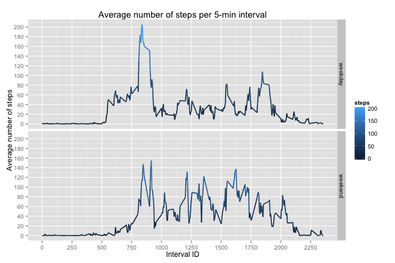

```r
mean_data_wday <- aggregate(steps ~ interval + wday, data = imputed_data, FUN = mean)

ggplot(data = mean_data_wday, aes(x = interval, y = steps)) +
        geom_line(aes(group = 1, col = steps), size = 0.8) +
        facet_grid(wday ~ .) +
        labs(title = "Average number of steps per 5-min interval", x = "Interval ID", y = "Average number of steps") +
        scale_x_continuous(breaks = seq(0, 2355, by = 250)) +
        scale_y_continuous(breaks = seq(0, 210, by = 20))
```

The weekday activity pattern shows large spike in the morning and a smaller one in the late afternoon. During the day, activity is relatively low. The weekend activity starts later in the day and there are no large spikes in the morning as in the weekdays. However, overall activity patterns are higher than during the weekdays and more evenly distributed. We could say that in general there is more activity during the weekend.

```r
summary(mean_data_wday$steps[mean_data_wday$wday == "weekday"])
```

```
##    Min. 1st Qu.  Median    Mean 3rd Qu.    Max.
##   0.000   1.922  20.780  31.150  45.930 205.400
```

```r
summary(mean_data_wday$steps[mean_data_wday$wday == "weekend"])
```

```
##     Min.  1st Qu.   Median     Mean  3rd Qu.     Max.
##   0.0000   0.9688  28.1600  38.1900  67.9400 155.0000
```